# Bayesian Decision Theory

João Neto

January 2015

Bayesian probability can process prior information and data to give us a posterior distribution that summarizes what we know about a given problem. That’s where the *inference problem* stops. That posterior does not include what action we should perform if there are several options to consider. To act we require extra information and that’s where the *decision problem* begins.

To build a decision problem we need to know:

- what are the possible **states**, $s \in S$, and their probability
- what are the possible **actions**, $a \in A$
- a **loss function**, $L(s,a)$ giving the loss of performing action $a$ if the *true state* is state $s$

## Vaccination example

This eg is from Stuart Coles [1999](http://homepages.dcc.ufmg.br/~assuncao/LDA/aulas/StuartColesBayes.pdf): There is a new vaccination plan against the flu. It is estimated that 60% of the entire population is immune to this flu strand. People with flu will miss work which means that there’s a work loss for society (cost 20 units), but there’s also a cost to vaccinate an already immune person (cost 8 units). We assume that there’s a negligible cost of vaccinate a non immune person and also not vaccinating an immune one. The decision problem is that. without any individual information, should we vaccinate one person?

The possible states are $S = \{s_1, s_2\}$, where $s_1$ means immune individual, and $s_2$ means vulnerable person. Notice that we don’t know this for sure, if we knew then this would have a trivial solution. We only know the 60% initial estimate, ie, $p(s_1)=0.6$ and $p(s_2)=0.4$. This was the inference part (eventually this distribution was found after sampling the entire population).

The possible actions are $A=\{a_1, a_2\}$, where $a_1$ means ‘vaccinate’ and $a_2$ means ‘not vaccinate’.

The loss function is

$\begin{array}{c|cc} L(s,a) & s_1 & s_2\\ \hline a_1 & 8 & 0 \\ a_2 & 0 & 20 \\ \end{array}$

The best decision is the one that minimizes the expected loss $E_S[L(s,a)]$:

```r
all_states   <- 1:2         # s_1 and s_2
prior_states <- c(0.6, 0.4) # p(s_1) and p(s_2)

loss <- function(a, s) {
  losses <- matrix( c(8, 0,
                      0,20), ncol=2, byrow=TRUE)
  losses[a,s]
}

# cost after deciding to vaccinate
action <- 1   # a_1
sum( loss(action, all_states) * prior_states) # compute expected loss of vaccination
```

```
## [1] 4.8
```

```r
# cost after deciding to not vaccinate
action <- 2   # a_2
sum( loss(action, all_states) * prior_states) # compute expected loss of non vaccination
```

```
## [1] 8
```

So the loss of not vaccinating is larger than vaccinating. The decision then is to vaccinate each individual person.

This decision might change if more data $D$ is provided. In this case we should go back to the inference step and remake the distribution over the known states to compute $p(S|D)$ before computing and minimize the new loss values.

Continuing with the vaccine eg, say that we have a cheap but not entirely reliable test for flu vulnerability that provides the values $x_1,x_2,x_3,x_4$ ($x_1$ meaning negligible response to $x_4$ meaning strong response) the following joint probability distribution:

$\begin{array}{c|cc} & p(x_i|s_1) & p(x_i|s_2) \\ \hline x_1 & 0.35 & 0.09 \\ x_2 & 0.30 & 0.17 \\ x_3 & 0.21 & 0.25 \\ x_4 & 0.14 & 0.49 \\ \end{array}$

Given the prior information regarding $S$, $p(S)$ and a data $x$, we use the conditional table for $p(x|S)$ and with Bayes Theorem compute $p(S|x)$.

```r
likelihood_x_states <- matrix(c(.35,.09,
                                .30,.17,
                                .21,.25,
                                .14,.49), ncol=2, byrow=TRUE)

posterior <- function(prior, likelihood, given_state, given_data) {

  evidence <- sum( likelihood[given_data,all_states] * prior )
  prior[given_state]*likelihood[given_data,given_state] / evidence
}

posterior_states <- matrix(rep(NA,8), ncol=2)
for(xi in 1:4)
  for(si in 1:2)
    posterior_states[xi,si] <- posterior(prior_states, likelihood_x_states, si, xi)

colnames(posterior_states) <- paste0("s",1:2)
rownames(posterior_states) <- paste0("p(S|x",1:4,")")
posterior_states
```

```
##                s1        s2
## p(S|x1) 0.8536585 0.1463415
## p(S|x2) 0.7258065 0.2741935
## p(S|x3) 0.5575221 0.4424779
## p(S|x4) 0.3000000 0.7000000
```

Again the inference problem is over: we have the posterior for the states given the data. To be able to find the best decision, we should recompute the expected losses.

The posterior expected loss is computed by

$\rho(a,x_i) = E_{S|x_i}[L(s,a)] = \sum_s L(s,a) p(s|x_i)$

```r
expected_loss <- matrix(rep(NA,8), ncol=2)

for(xi in 1:4)
  for(action in 1:2)
    expected_loss[xi,action] <- sum(loss(action,all_states) * posterior_states[xi,all_states])

colnames(expected_loss) <- paste0("a",1:2)
rownames(expected_loss) <- paste0("E[L(S,a)|x",1:4,")")
expected_loss
```

```
##                    a1        a2
## E[L(S,a)|x1) 6.829268  2.926829
## E[L(S,a)|x2) 5.806452  5.483871
## E[L(S,a)|x3) 4.460177  8.849558
## E[L(S,a)|x4) 2.400000 14.000000
```

In this case we see that the best action is not always vaccinate (action $a_1$ which is in the first column). We only should vaccinate if the test returns $x_3$ or $x_4$, ie, when the test returns strong responses of vulnerability.

The decision/policy $d(x_i)$ is the action $a$ with minimum posterior expected loss:

$d(x_i) = \arg\min_a \rho(a,x_i)$

```r
d <- function(xi) {
  which.min(expected_loss[xi,])
}

d(1) # we observed x1 (the action should be a_2, ie, not vaccinate)
## a2
##  2
d(3) # we observed x3 (the action should be a_1, ie, vaccinate)
## a1
##  1
```

We can compute the risk associated with a given policy $d(x)$ by averaging the losses across the uncertainty of the data $x_i$, which is called the **Bayes risk**:

$BR(d) = \sum_x \rho(d(x),x) p(x)$

```r
# compute marginal probabilities p(xi)
marginals <- likelihood_x_states %*% prior_states
marginals
```

```
##       [,1]
## [1,] 0.246
## [2,] 0.248
## [3,] 0.226
## [4,] 0.280
```

```r
bayes_risk <- function(d) {
  risk <- 0
  for(xi in 1:4) {
    decision      <- d(xi)
    decision_loss <- expected_loss[xi,decision]
    risk <- risk + decision_loss * marginals[xi]
  }
  risk
}

bayes_risk(d)  # expected loss per individual
```

```
## [1] 3.76
```

Let’s compare against the policy of universal vaccination:

```r
bayes_risk(function(xi) 1)  # always choose action 1, ie, vaccinate
```

```
## [1] 4.8
```

Or the policy to not vaccinate everyone:

```r
bayes_risk(function(xi) 2)  # always choose action 2, ie, not vaccinate
```

```
## [1] 8
```

Or the policy to first flip a coin to decide between actions $a_1$ and $a_2$ (let’s simulate to estimate the mean risk):

```r
n_sims <- 1e3
sims   <- replicate(n_sims, bayes_risk(function(xi) sample(1:2,1)))
mean(sims)
```

```
## [1] 6.484944
```

which is a better policy than universal non-vaccination, *in the context of the selected loss function*.

## 2D Searching

This is based on the Rasmus Bååth’s blog [post](http://www.sumsar.net/blog/2015/01/probable-points-and-credible-intervals-part-two/) about a 1D searching for a robot.

We are searching for the Robo robot that disappeared again, but now in a 2D world map.

The team made some inferences regarding the available information and produced a sampling of the posterior distribution for Robo’s position:

```r
library(mvtnorm) # rmvnorm

landscape_sizex <- 60  # the size of the landscape
landscape_sizey <- 30

# build a posterior sample
posterior_sample <- function(n) {
  dist_i <- sample(3, n, replace = TRUE, c(32, 18, 50)) # from which distribution to sample
  # params of the three distributions
  mu_x <- c(40, 15, 25)
  mu_y <- c(15, 25, 10)
  mu <- matrix(c(mu_x,mu_y),ncol=2)
  sigma <- c(2*diag(2), 4*diag(2), 15*diag(2))
  dim(sigma) <- c(2,2,3)
  # create the posterior sample
  post <- matrix(rep(NA,2*n), ncol=2)
  for (i in 1:n)
    post[i,] <- rmvnorm(1, mean=mu[dist_i[i],], sigma=sigma[,,dist_i[i]])
  post <- post[post[,1] >= 0 & post[,1] <= landscape_sizex,]
  post[post[,2] >= 0 & post[,2] <= landscape_sizey,]
}

s <- posterior_sample(5e3)  # the available posterior sample
```

Let’s produce a density for this sample to vizualize what we have:

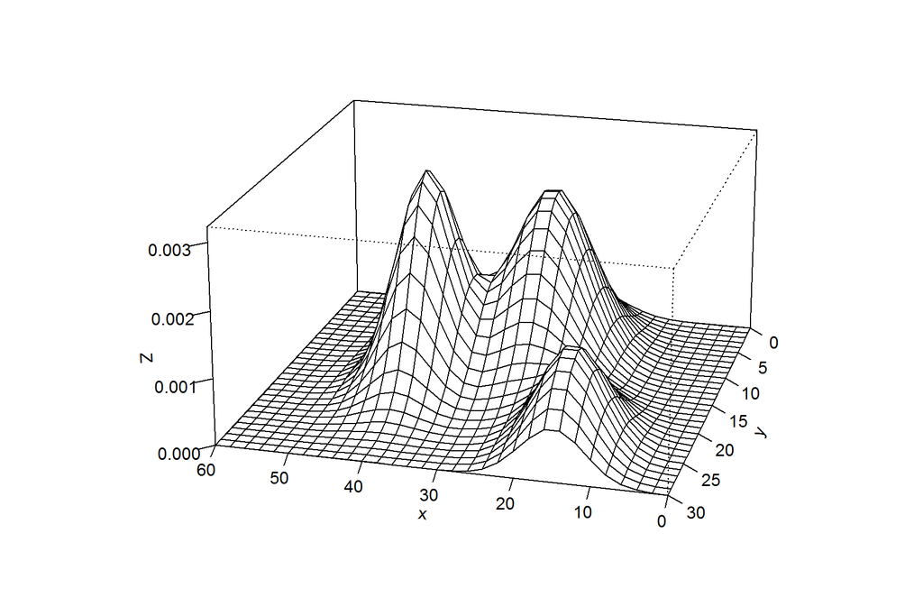

```r
library(MASS)
n_grid <- 31
s_dens <- kde2d(s[,1], s[,2], 15, n=n_grid, lims = c(0,landscape_sizex,0,landscape_sizey))
persp(s_dens, phi = 20, theta = 195, d=5, xlab="x", ylab="y", expand = 0.5, ticktype = "detailed")
```

Let’s try using the standard loss functions, here in a 2D version (adapted from Rasmus’s code):

```r
library(fields)  # for 2D interpolation

L0 <- function(x, s) {
  -interp.surface(s_dens, matrix(c(x[1],x[2]), ncol=2))  # proportional to L0 loss
}

L1 <- function(x, s) {
  sum(c(abs(x[1]-s[,1]),abs(x[2]-s[,2])))
}

L2 <- function(x, s) {
  sum(apply(s,1,function(si) sum((si-x)^2)))
}
```

Some useful functions:

```r
# apply normalization to [0,1]
normalize_0_1 <- function(x) {
  (x-min(x))/(max(x)-min(x))
}

# compute the loss value for each value of the posterior sample
grid_loss <- function(loss_function, s, ...) {
  f <- function(x,y) loss_function(c(x,y), s, ...)
  outer(1:landscape_sizex, 1:landscape_sizey, Vectorize(f))
}

# where is the minimum loss value given a matrix?
point_estimate <- function(grid) {
  which(grid == min(grid), arr.ind = TRUE)[1,] # if there are several solutions, pick the first
}

# to plot a grid like the loss function
draw_grid <- function(grid, title="Loss Function", pallete=c("blue","cyan"),
                            n_colors=15, zaxis="loss", drawPt=TRUE) {
  best_p    <- point_estimate(grid)         # the best estimate (minimum loss)
  best_loss <- grid[best_p[1], best_p[2]]   # its loss value
  # plot the loss function in perspective
  color <- colorRampPalette(pallete)(n_colors)
  nrz <- nrow(grid)
  ncz <- ncol(grid)
  zfacet <- grid[-1, -1] + grid[-1, -ncz] + grid[-nrz, -1] + grid[-nrz, -ncz]
  facetcol <- cut(zfacet, n_colors)
  p_plot <- persp(grid, phi = 20, theta = 195, d=5, expand = 0.5,
                  xlab="x", ylab="y", zlab=zaxis, col = color[facetcol], main=title)
  # put a dot where's the minimum loss
  if (drawPt)
    points(trans3d(best_p[1]/landscape_sizex, best_p[2]/landscape_sizey, best_loss, pmat = p_plot), col = 2, pch = 16)
}
```

Let’s compute and show the values for different loss functions:

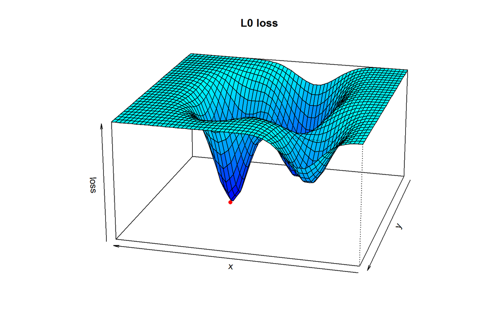

```r
loss_L0 <- normalize_0_1(grid_loss(L0, s))
draw_grid(loss_L0, title="L0 loss")
```

```r
point_estimate(loss_L0)
```

```
## row col
##  40  15
```

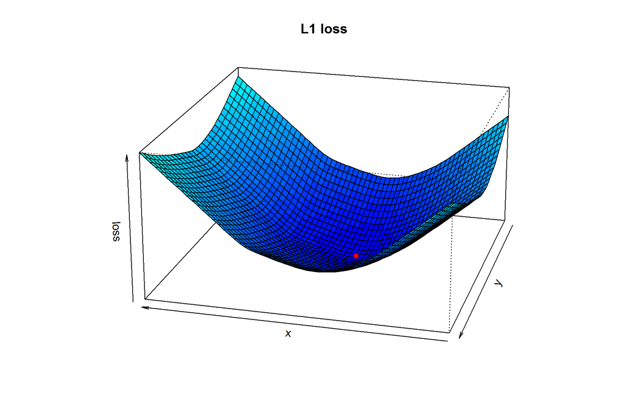

```r
loss_L1 <- normalize_0_1(grid_loss(L1, s))
draw_grid(loss_L1, title="L1 loss")
```

```r
point_estimate(loss_L1)
```

```
## row col
##  26  14
```

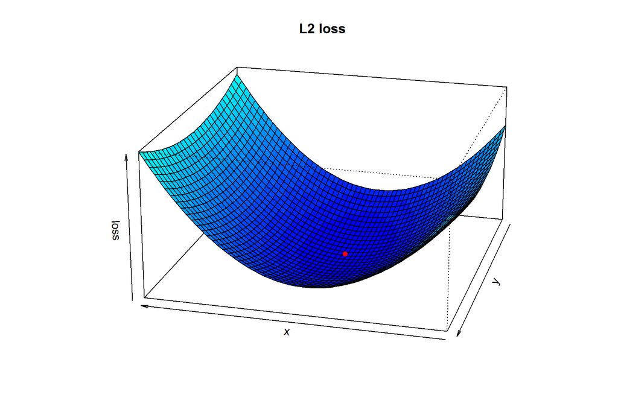

```r
loss_L2 <- normalize_0_1(grid_loss(L2, s))
draw_grid(loss_L2, title="L2 loss")
```

```r
point_estimate(loss_L2)
```

```
## row col
##  28  14
```

Say we had to choose a point in the landscape where a satellite could run its search algorithm and be able to find Robot but only within a given maximum distance. What is the best point?

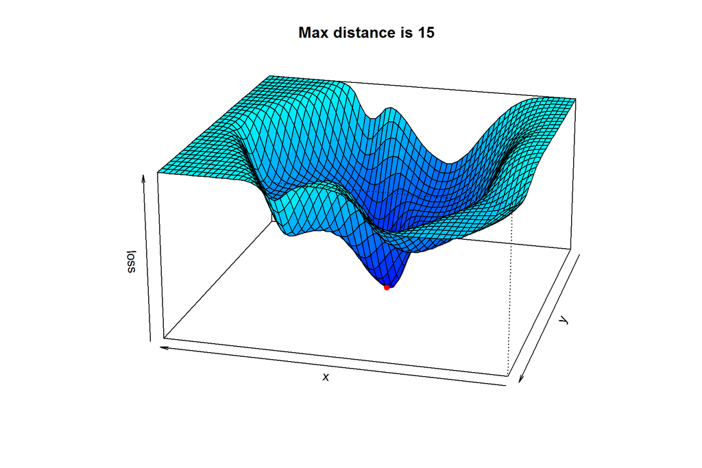

```r
# minimize the number of grid points that are not searched by the satellite, given their posterior densities
limited_dist_loss <- function(x, s, max_dist) {
  # check how many grid points we will *not* find RObo
  mean((abs(x[1]-s[,1]) + abs(x[2]-s[,2]))^2 > max_dist^2) # Euclidean distance
}

max_dist <- 15

loss_dist <- normalize_0_1(grid_loss(limited_dist_loss, s, max_dist))
draw_grid(loss_dist, title=paste("Max distance is", max_dist))
```

```r
point_estimate(loss_dist)
```

```
## row col
##  29  14
```

If the satellite is very good (covers a long distance) the decision problem becomes less problematic, as we can see in this next instance:

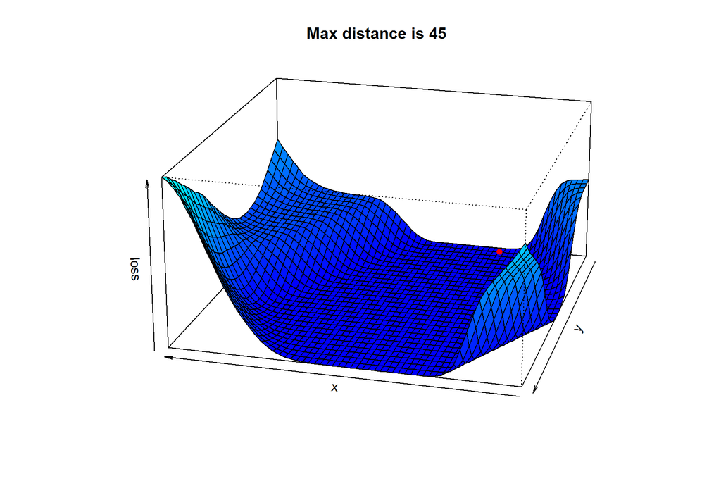

```r
max_dist <- 45

loss_dist <- normalize_0_1(grid_loss(limited_dist_loss, s, max_dist))
draw_grid(loss_dist, title=paste("Max distance is", max_dist))
```

Let’s assume the map is a landscape with different types of terrain with different search cost values:

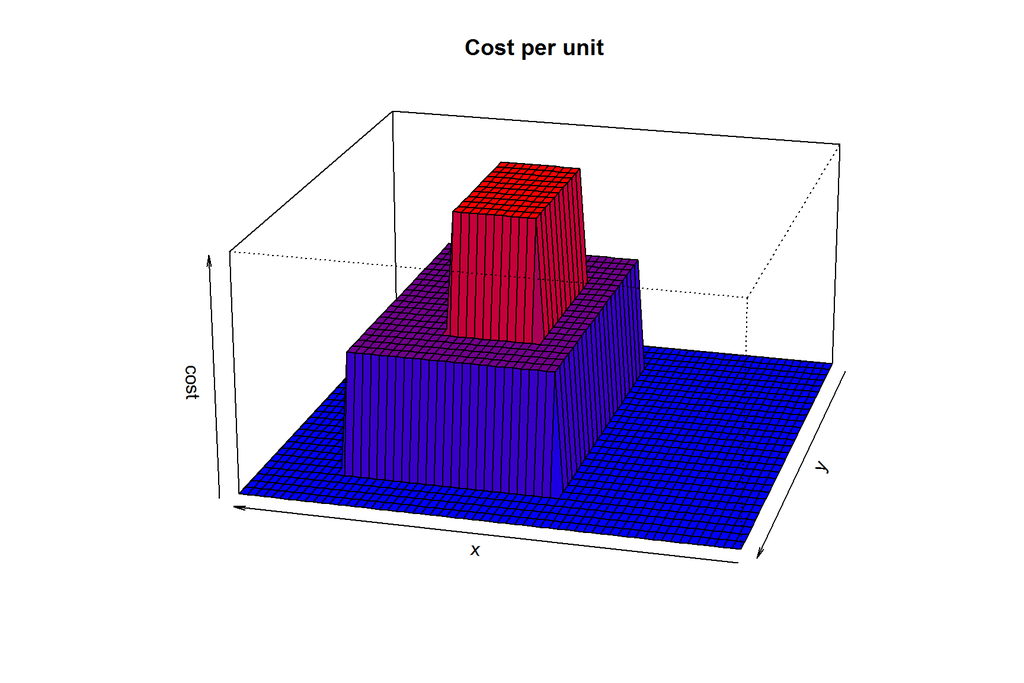

```r
landscape_cost  <- c(mountain = 5, forest = 3, plain = 1)

landscape <- matrix( rep(landscape_cost['plain'], landscape_sizex*landscape_sizey), ncol=landscape_sizey)
landscape[25:50, 5:25] <- landscape_cost['forest']
landscape[30:40,10:20] <- landscape_cost['mountain']

draw_grid(landscape, "Cost per unit", c("blue","red"), 10, "cost", FALSE)
```

Say we could search a square up to $7\times 7$ and had a budget of $175$. What would be the best choice?

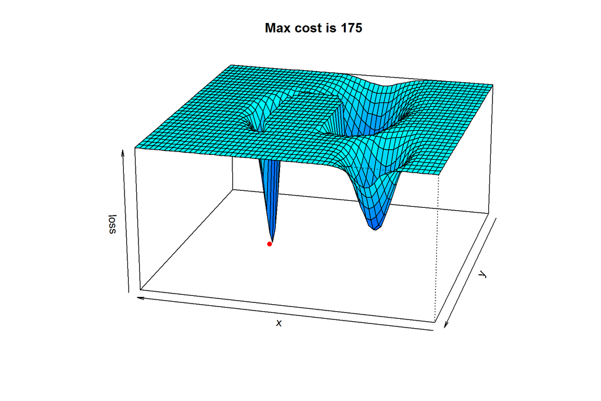

```r
max_cost    <- 175
max_sq_size <- 7

limited_cost_loss <- function(x, s, max_cost) { # x is the 5x5 square's center coordinate
  # find the correct square limits (important at landscape edges)
  min.x <- max(x[1]-max_sq_size%/%2, 1)
  min.y <- max(x[2]-max_sq_size%/%2, 1)
  max.x <- min(x[1]+max_sq_size%/%2, landscape_sizex)
  max.y <- min(x[2]+max_sq_size%/%2, landscape_sizey)

  if (sum(landscape[min.x:max.x, min.y:max.y]) > max_cost) {
    result = 1 # max possible cost for limited_dist_loss is 1
  } else {
    result = limited_dist_loss(x, s, 1.414214*max_sq_size%/%2) # sqrt(2)*size half square
  }

  result
}

loss_cost <- normalize_0_1(grid_loss(limited_cost_loss, s, max_cost))
draw_grid(loss_cost, title=paste("Max cost is", max_cost))
```

```r
point_estimate(loss_cost) # the center of the search square
```

```
## row col
##  42  15
```

Let’s try a tighter budget:

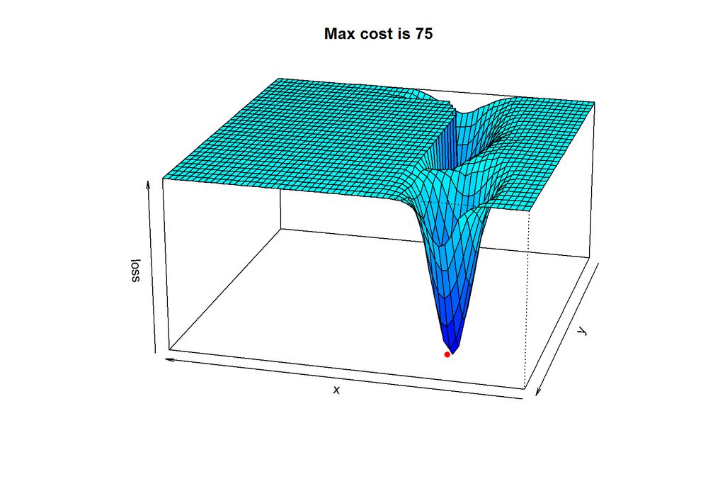

```r
max_cost    <- 75

loss_cost <- normalize_0_1(grid_loss(limited_cost_loss, s, max_cost))
draw_grid(loss_cost, title=paste("Max cost is", max_cost))
```

```r
point_estimate(loss_cost) # the center of the search square
```

```
## row col
##  15  25
```

The decision is to explore the plains near the right peak, since we cannot afford to search the mountain, where it lies the higher posterior density.

And if we have unlimited budget to select our best area?

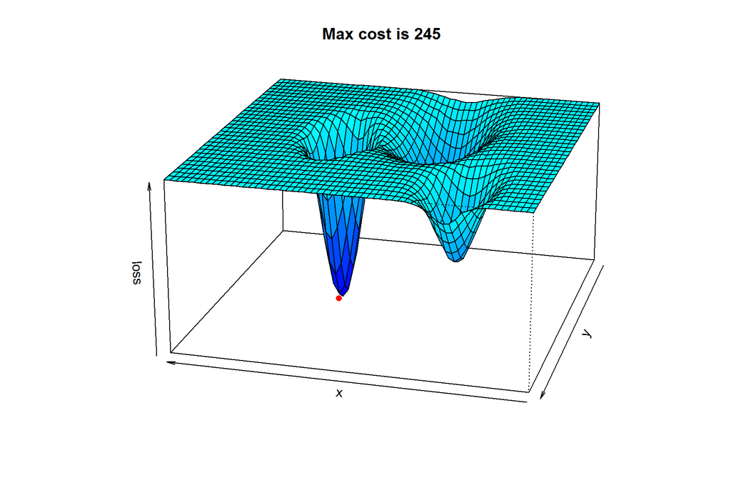

```r
max_cost    <- landscape_cost['mountain'] * max_sq_size^2 # maximum possible budget

loss_cost <- normalize_0_1(grid_loss(limited_cost_loss, s, max_cost))
draw_grid(loss_cost, title=paste("Max cost is", max_cost))
```

```r
point_estimate(loss_cost) # the center of the search square
```

```
## row col
##  40  15
```

which is similar to the L0 cost function (not exactly sure why, thou :-).